# Session 8. Working with dates and strings in R. Getting financial and economic data from APIs

Parandzem Sargsyan, AUA, Metric

psargsyan@aua.am

October 6, 2019

Supplementary reading material: [R for Data Science, Hadley Wickham & Garrett Grolemund](https://www.bioinform.io/site/wp-content/uploads/2018/09/RDataScience.pdf)

# Dates

To work with dates and times in R, `lubridate package` can be used.

```r
library(tidyverse)
library(lubridate)
library(nycflights13)
```

Getting the current date or date-time:

```r
today()
```

```
[1] "2019-10-14"
```

```r
now()
```

```
[1] "2019-10-14 13:32:06 +04"
```

`ymd`, `myd`,`dmy` functions convert strings into date-time format.

```r
ymd("2019-05-20")
```

```
[1] "2019-05-20"
```

```r
ymd('20190520')
```

```
[1] "2019-05-20"
```

```r
myd("05/2019/20")
```

```
[1] "2019-05-20"
```

```r
dmy("20 May 2019")
```

```
[1] "2019-05-20"
```

In order to separate only year or month or day from the date, the following functions can be used:

```r
year("2019-12-13 15:30:30") #separating year
```

```
[1] 2019
```

```r
month("2019-12-13 15:30:30") #separating month
```

```
[1] 12
```

```r
mday("2019-12-13 15:30:30") #separating day
```

```
[1] 13
```

```r
minute("2019-12-13 15:30:30") #separating minutes
```

```
[1] 30
```

```r
second("2019-12-13 15:30:30") #separating seconds
```

```
[1] 30
```

```r
hour("2019-12-13 15:30:30") #separating hours
```

```
[1] 15
```

Durations display as the number of seconds in a time span.

```r
duration(1, "day")
```

```
[1] "86400s (~1 days)"
```

```r
duration(1.5, "minutes")
```

```
[1] "90s (~1.5 minutes)"
```

```r
duration(-1, "days")
```

[output not shown]

Let’s see what are the time components in flight data from `nycflights13` package.

```r
flights<-nycflights13::flights
head(flights)
```

| year | month | day | dep_time | sched_dep_time | dep_delay | arr_time | sched_arr_time | arr_delay | carrier | flight | tailnum | origin | dest | air_time | distance | hour | minute | time_hour |
| --- | --- | --- | --- | --- | --- | --- | --- | --- | --- | --- | --- | --- | --- | --- | --- | --- | --- | --- |
| 2013 | 1 | 1 | 517 | 515 | 2 | 830 | 819 | 11 | UA | 1545 | N14228 | EWR | IAH | 227 | 1400 | 5 | 15 | 2013-01-01 05:00:00 |
| 2013 | 1 | 1 | 533 | 529 | 4 | 850 | 830 | 20 | UA | 1714 | N24211 | LGA | IAH | 227 | 1416 | 5 | 29 | 2013-01-01 05:00:00 |
| 2013 | 1 | 1 | 542 | 540 | 2 | 923 | 850 | 33 | AA | 1141 | N619AA | JFK | MIA | 160 | 1089 | 5 | 40 | 2013-01-01 05:00:00 |
| 2013 | 1 | 1 | 544 | 545 | -1 | 1004 | 1022 | -18 | B6 | 725 | N804JB | JFK | BQN | 183 | 1576 | 5 | 45 | 2013-01-01 05:00:00 |
| 2013 | 1 | 1 | 554 | 600 | -6 | 812 | 837 | -25 | DL | 461 | N668DN | LGA | ATL | 116 | 762 | 6 | 0 | 2013-01-01 06:00:00 |
| 2013 | 1 | 1 | 554 | 558 | -4 | 740 | 728 | 12 | UA | 1696 | N39463 | EWR | ORD | 150 | 719 | 5 | 58 | 2013-01-01 05:00:00 |

**Class Exercise**: Select only variables which refer to data.

**Solution**

```r
date_data<-flights %>%
  select(year,month,day,hour,minute)
date_data
```

| year | month | day | hour | minute |
| --- | --- | --- | --- | --- |
| 2013 | 1 | 1 | 5 | 15 |
| 2013 | 1 | 1 | 5 | 29 |
| 2013 | 1 | 1 | 5 | 40 |
| 2013 | 1 | 1 | 5 | 45 |
| 2013 | 1 | 1 | 6 | 0 |
| 2013 | 1 | 1 | 5 | 58 |
| 2013 | 1 | 1 | 6 | 0 |
| 2013 | 1 | 1 | 6 | 0 |
| 2013 | 1 | 1 | 6 | 0 |
| 2013 | 1 | 1 | 6 | 0 |

[output cut: 990 more lines]

Let’s use `make_datetime()` to create new column with full date, which we will call full_date.

```r
date_data<-date_data %>%
  mutate(full_date = make_datetime(year, month, day, hour, minute))
date_data
```

| year | month | day | hour | minute | full_date |
| --- | --- | --- | --- | --- | --- |
| 2013 | 1 | 1 | 5 | 15 | 2013-01-01 05:15:00 |
| 2013 | 1 | 1 | 5 | 29 | 2013-01-01 05:29:00 |
| 2013 | 1 | 1 | 5 | 40 | 2013-01-01 05:40:00 |
| 2013 | 1 | 1 | 5 | 45 | 2013-01-01 05:45:00 |
| 2013 | 1 | 1 | 6 | 0 | 2013-01-01 06:00:00 |
| 2013 | 1 | 1 | 5 | 58 | 2013-01-01 05:58:00 |
| 2013 | 1 | 1 | 6 | 0 | 2013-01-01 06:00:00 |
| 2013 | 1 | 1 | 6 | 0 | 2013-01-01 06:00:00 |
| 2013 | 1 | 1 | 6 | 0 | 2013-01-01 06:00:00 |
| 2013 | 1 | 1 | 6 | 0 | 2013-01-01 06:00:00 |

[output cut: 990 more lines]

**Class Excercise**: Visualise the distribution of flights for January 2013 (the width of the bins is one day)

**Solution**

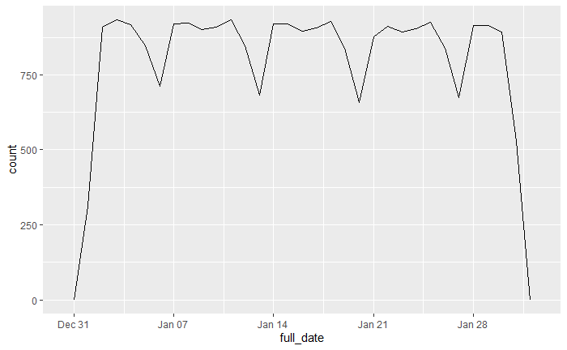

```r
date_data %>%
  filter(full_date< ymd(20130131)) %>%
  ggplot(aes(full_date))+
    geom_freqpoly(binwidth = 86400) #let's put the width of bin equal to 1 day which is seconds (see above)
```

# Strings with stringr

To work with strings, we need to install `stringr` package.

### Basic Functions

Prerequisites (run the libraries before starting coding):

- `library(tidyverse)`
- `library(stringr)`

```r
library(stringr)
```

Strings can be created with either single quotes or double quotes (`'` or `"`). If a string has " inside it, R will interpret the double quote as the end of the string, in this case single quote, ‘, should be used to define the string. Finally, there are cases where you need both’ and " inside the string. In this case, double quote " shuld be used to define the string, but you’ll have to escape any double quotes inside the string using a backslash (i.e. ").

```r
name<-"Parandzem"
surname<-"Sargsyan"
```

Sentence which includes `""` within `' '`.

```r
str_1<-'My second name is "Sargsyan".'
str_1
```

```
[1] "My second name is \"Sargsyan\"."
```

IIf sentence includes both `" "` and `' '` then backslash (`\`) should be used to create string.

```r
str_2<-"My 'second name' is \"Sargsyan\"."
str_2
```

```
[1] "My 'second name' is \"Sargsyan\"."
```

To show the final output of the text, use `writeLines()`:

```r
writeLines(str_2)
```

```
My 'second name' is "Sargsyan".
```

Multiple strings are often stored in a character vector, which can be create with `c()`:

```r
name_surn<-c("Parandzem", "Sargsyan")
name_surn
```

```
[1] "Parandzem" "Sargsyan"
```

From `stringr` let’s use several functions to explore some attributes of strings.

Let’s get the length of name_surn:

```r
str_length(name_surn)
```

```
[1] 9 8
```

The output above shows that the first string of name_surn vector has 9 characters and the second one 8. Let’s combine the strings:

```r
str_c(name,surname)
```

```
[1] "ParandzemSargsyan"
```

```r
nm_srn<-str_c(name,surname, sep = " ")
nm_srn
```

```
[1] "Parandzem Sargsyan"
```

Making strings lower and upper cases:

```r
str_to_lower(nm_srn)
```

```
[1] "parandzem sargsyan"
```

```r
str_to_upper(nm_srn)
```

```
[1] "PARANDZEM SARGSYAN"
```

```r
str_to_title(nm_srn)
```

```
[1] "Parandzem Sargsyan"
```

Extracting parts of the string:

```r
#let's extract only numbers
ids<-c("ID111","ID114","ID113")
str_sub(ids,3,5) #first number is the start of 1st character,2nd number indicates the position                   of the last character
```

```
[1] "111" "114" "113"
```

Sorting strings:

```r
fruits<-c("Banana", "apple", "peach")
str_sort(fruits) #returns strings
```

```
[1] "apple"  "Banana" "peach"
```

```r
str_sort(ids, numeric = TRUE) #sorting only numeric part of the strings
```

```
[1] "ID111" "ID113" "ID114"
```

```r
str_order(fruits) #returns position numbers
```

```
[1] 2 1 3
```

### Regular expressions

**Regular expressions are a concise and flexible tool for describing patterns in strings.**

`str_view()` shows the first match.

```r
str_view(fruits,"an")
```

[interactive chart not shown]

`str_view_all()` shows all the matches.

```r
str_view_all(fruits,"an") #"an" is the pattern to look for in the strings
```

[interactive chart not shown]

```r
#let's create new list of words
countries<-c("Republic of Armenia", "Republic of Georgia", "The Kingdom of Belgium", "United Kingdom")
```

- `^` should be used to match the start of the string.
- `$` should be used to match the end of the string.

Some useful regular expressions to match strings:

```r
str_view(countries, "Kingdom") #match any word including Kingdom
```

[interactive chart not shown]

```r
str_view(countries, "^R") #match countries starting with "R""
```

[interactive chart not shown]

```r
str_view(countries, "ia$") #match countries ending with "ia"
```

[interactive chart not shown]

```r
str_view(countries, "^United Kingdom$") #only matches a complete string
```

[interactive chart not shown]

`str_detect()` detects the presence or absence of a pattern in a string.

```r
str_detect(countries,'Kingdom')
```

```
[1] FALSE FALSE  TRUE  TRUE
```

If we want to see, how many of the country names have word “Kingdom”, we can use `sum()` function.

```r
sum(str_detect(countries,'Kingdom'))
```

```
[1] 2
```

So, two words have Kingdom.

# Getting financial and economic data from APIs

The picture below shows financial data sources that can be access in R through different backages.

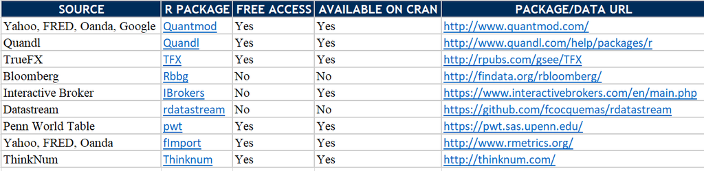

Source: https://www.r-bloggers.com/financial-data-accessible-from-r-part-iii/

## Packages

Packages that we will explore are:

- `Quantmod`: Provides a framework for quantitative financial modeling and trading. It provides a rapid prototyping environment that makes modeling easier by removing the repetitive workflow issues surrounding data management and visualization. For more information go to https://cran.r-project.org/web/packages/quantmod/quantmod.pdf.
- `Quandl` : Functions for interacting directly with the Quandl API to offer data in a number of formats usable in R, downloading a zip with all data from a Quandl database, and the ability to search. This R package uses the Quandl API. For more information go to https://www.quandl.com/docs/api.

## quantmod

*`getSymbols()`*

*Quantitative Financial Modelling Framework*: The `quantmod package` for R is designed to assist the quantitative trader in the development, testing, and deployment of statistically based trading models.

Let’s install `quantmod` package.

```r
#install.packages('quantmod')
library(quantmod)
```

```r
getSymbols(Symbols = "AAPL",
           src = "yahoo"
)
```

[output not shown]

```
[1] "AAPL"
```

```r
head(AAPL)
```

```
           AAPL.Open AAPL.High AAPL.Low AAPL.Close AAPL.Volume AAPL.Adjusted
2007-01-03  12.32714  12.36857 11.70000   11.97143   309579900      10.44763
2007-01-04  12.00714  12.27857 11.97429   12.23714   211815100      10.67952
2007-01-05  12.25286  12.31428 12.05714   12.15000   208685400      10.60347
2007-01-08  12.28000  12.36143 12.18286   12.21000   199276700      10.65583
2007-01-09  12.35000  13.28286 12.16429   13.22429   837324600      11.54101
2007-01-10  13.53571  13.97143 13.35000   13.85714   738220000      12.09331
```

Let’s import GDP of Georgia by defining the sources of data:

```r
getSymbols(Symbols = "MKTGDPGEA646NWDB",
           src = "FRED"
)
```

```
[1] "MKTGDPGEA646NWDB"
```

```r
head(AAPL)
```

```
           AAPL.Open AAPL.High AAPL.Low AAPL.Close AAPL.Volume AAPL.Adjusted
2007-01-03  12.32714  12.36857 11.70000   11.97143   309579900      10.44763
2007-01-04  12.00714  12.27857 11.97429   12.23714   211815100      10.67952
2007-01-05  12.25286  12.31428 12.05714   12.15000   208685400      10.60347
2007-01-08  12.28000  12.36143 12.18286   12.21000   199276700      10.65583
2007-01-09  12.35000  13.28286 12.16429   13.22429   837324600      11.54101
2007-01-10  13.53571  13.97143 13.35000   13.85714   738220000      12.09331
```

If we want to get Symbol name from FRED, we need to go https://fred.stlouisfed.org/ and search for the series we want to download.

From `quantmod`, we can use `chartSeries()` function to visualise time series data.

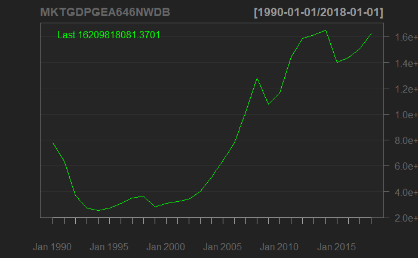

```r
chartSeries(MKTGDPGEA646NWDB) #visualise GDP time-series data
```

## Quandl

*`Quandl()`*

For more information, please visit https://docs.quandl.com/#retrieve-data-and-metadata.

Differences between Quandl() and getSymbols() are:

- `GetSymbols()` uses the `Symbols` and `src` arguments to specify the instrument and data source, respectively, while `Quandl()` specifies both the data source and the instrument via its code argument, in the form “DATABASE/DATASET”
- `Quandl()` returns a *data.frame* by default while `GetSymbols()` returns xts.
- `Quandl()` will not automatically assign the data to an object while ``GetSymbols()` assigns.

*Note:* If you plan on importing a lot of data using Quandl(), you might consider opening a free account with them in order to get an API key. In order to sign in and to get your `Quandl API KEY`, go here: https://www.quandl.com/sign-up-modal.

To start, first we need to install quandl package:

```r
#install.packages('Quandl')
library(Quandl)
```

```r
Quandl.api_key('a-ycygX1AtQCZexCc4a5')
```

In order not to go to the Quandl website every single time when we need to download a new dataset in R, we can use `Quandl.search()`function to find Quandl database where we can download the data. The output of search results is dataframe.

```r
search_aapl<-Quandl.search("AMZN",
                           per_page = 20, #how many data sources to return
                           silent = TRUE #not to show the description of each data source
)
search_aapl
```

|  | id | dataset_code | database_code | name | description | refreshed_at | newest_available_date | oldest_available_date | column_names | frequency | type | premium | database_id |
| --- | --- | --- | --- | --- | --- | --- | --- | --- | --- | --- | --- | --- | --- |
| 1 | 11223319 | FNRA_AMZN | FINRA | ADF Short Interest: AMZN | This dataset has no description. | 2017-11-01T00:22:24.938Z | 2016-11-30 | 2014-02-18 |  | daily | Time Series | FALSE | 7370 |
| 2 | 23546334 | AMZN | OPT | AMZN Volatility & Option Implied Surface | Implied volatility surface for AMZN.For more information please view OPT Documentation. | 2019-10-12T00:25:35.878Z | 2019-10-11 | 2010-01-04 |  | daily | Time Series | TRUE | 13064 |
| 3 | 11179443 | FNSQ_AMZN | FINRA | FINRA/NASDAQ TRF Short Interest: AMZN | FINRA/NASDAQ TRF Short Interest: AMZN | 2019-10-12T00:26:11.756Z | 2019-10-11 | 2013-04-01 |  | daily | Time Series | FALSE | 7370 |
| 4 | 11187543 | FNYX_AMZN | FINRA | FINRA/NYSE TRF Short Interest: AMZN | FINRA/NYSE TRF Short Interest: AMZN | 2019-10-12T00:27:17.222Z | 2019-10-11 | 2013-04-01 |  | daily | Time Series | FALSE | 7370 |
| 5 | 37286291 | AMZN_UADJ | XNAS | Amazon.com Inc. (AMZN) Unadjusted Stock Prices | Ticker: AMZN Exchange: XNAS Columns: Open,High,Low,Close,Volume are unadjusted and shown in USD currency. Adjustment Factor shows the factor by which prices are adjusted on days which adjustments take… | 2019-10-12T02:11:07.987Z | 2019-10-11 | 2006-12-28 |  | daily | Time Series | TRUE | 14999 |
| 6 | 37588120 | AMZN | XASE | Amazon.com Inc. (AMZN) Adjusted Stock Prices | Ticker: AMZN Exchange: XASE Columns: Open,High,Low,Close,Volume are adjusted and shown in USD currency. Adjustment Factor shows the factor by which prices are adjusted on days which adjustments take p… | 2019-10-12T02:08:36.249Z | 2019-10-11 | 2006-12-27 |  | daily | Time Series | TRUE | 15101 |
| 7 | 37884616 | AMZN | XNAS | Amazon.com Inc. (AMZN) Adjusted Stock Prices | Ticker: AMZN Exchange: XNAS Columns: Open,High,Low,Close,Volume are adjusted and shown in USD currency. Adjustment Factor shows the factor by which prices are adjusted on days which adjustments take p… | 2019-10-12T02:11:07.985Z | 2019-10-11 | 2006-12-28 |  | daily | Time Series | TRUE | 14999 |
| 8 | 37218061 | AMZN_UADJ | XASE | Amazon.com Inc. (AMZN) Unadjusted Stock Prices | Ticker: AMZN Exchange: XASE Columns: Open,High,Low,Close,Volume are unadjusted and shown in USD currency. Adjustment Factor shows the factor by which prices are adjusted on days which adjustments take… | 2019-10-12T02:08:36.201Z | 2019-10-11 | 2006-12-27 |  | daily | Time Series | TRUE | 15101 |
| 9 | 37304215 | AMZN_UADJ | XNYS | Amazon.com Inc. (AMZN) Unadjusted Stock Prices | Ticker: AMZN Exchange: XNYS Columns: Open,High,Low,Close,Volume are unadjusted and shown in USD currency. Adjustment Factor shows the factor by which prices are adjusted on days which adjustments take… | 2019-10-12T02:54:17.281Z | 2019-10-11 | 2017-07-03 |  | daily | Time Series | TRUE | 15066 |
| 10 | 37811976 | AMZN | XNYS | Amazon.com Inc. (AMZN) Adjusted Stock Prices | Ticker: AMZN Exchange: XNYS Columns: Open,High,Low,Close,Volume are adjusted and shown in USD currency. Adjustment Factor shows the factor by which prices are adjusted on days which adjustments take p… | 2019-10-12T02:54:17.299Z | 2019-10-11 | 2017-07-03 |  | daily | Time Series | TRUE | 15066 |

[output cut: 10 more lines]

```r
aapl<-Quandl(code = "QOR/AMZN", #specifing both the data source and symbol here
             start_date=ymd("2015-01-01"), #putting time limits
             ends_with=ymd("2018-01-01")
)
```

```
Error: {"quandl_error":{"code":"QEPx04","message":"You do not have permission to view this dataset. Please subscribe to this database to get access."}}
```

Let’s download GDP of Georgia from 2001.

```r
GDP_Geo<-Quandl("FRED/DDOI11GEA156NWDB",
             start_date=ymd("2001-01-01")
)
GDP_Geo
```

| Date | Value |
| --- | --- |
| 2017-01-01 | 11.83400 |
| 2016-01-01 | 10.57720 |
| 2015-01-01 | 10.42440 |
| 2014-01-01 | 12.03250 |
| 2013-01-01 | 12.05250 |
| 2012-01-01 | 11.17040 |
| 2011-01-01 | 10.71920 |
| 2010-01-01 | 10.17250 |
| 2009-01-01 | 10.32450 |
| 2008-01-01 | 8.32370 |

[output cut: 7 more lines]

Let’s plot the data:

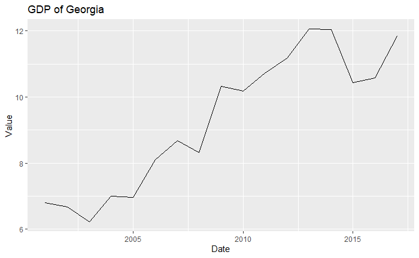

```r
GDP_Geo %>%
  ggplot(aes(Date, Value)) +
  geom_line()+
  ggtitle("GDP of Georgia")
```